# Student Name : Bismi Poulose

# Student ID : 8981107

# PART 1

## 1. Get the data

```python
from sklearn import datasets
diabetes_data = datasets.load_diabetes(as_frame=True)
df = diabetes_data.frame
df
```

|  | age | sex | bmi | bp | s1 | s2 | s3 | s4 | s5 | s6 | target |
| --- | --- | --- | --- | --- | --- | --- | --- | --- | --- | --- | --- |
| 0 | 0.038076 | 0.050680 | 0.061696 | 0.021872 | -0.044223 | -0.034821 | -0.043401 | -0.002592 | 0.019907 | -0.017646 | 151.0 |
| 1 | -0.001882 | -0.044642 | -0.051474 | -0.026328 | -0.008449 | -0.019163 | 0.074412 | -0.039493 | -0.068332 | -0.092204 | 75.0 |
| 2 | 0.085299 | 0.050680 | 0.044451 | -0.005670 | -0.045599 | -0.034194 | -0.032356 | -0.002592 | 0.002861 | -0.025930 | 141.0 |
| 3 | -0.089063 | -0.044642 | -0.011595 | -0.036656 | 0.012191 | 0.024991 | -0.036038 | 0.034309 | 0.022688 | -0.009362 | 206.0 |
| 4 | 0.005383 | -0.044642 | -0.036385 | 0.021872 | 0.003935 | 0.015596 | 0.008142 | -0.002592 | -0.031988 | -0.046641 | 135.0 |
| ... | ... | ... | ... | ... | ... | ... | ... | ... | ... | ... | ... |
| 437 | 0.041708 | 0.050680 | 0.019662 | 0.059744 | -0.005697 | -0.002566 | -0.028674 | -0.002592 | 0.031193 | 0.007207 | 178.0 |
| 438 | -0.005515 | 0.050680 | -0.015906 | -0.067642 | 0.049341 | 0.079165 | -0.028674 | 0.034309 | -0.018114 | 0.044485 | 104.0 |
| 439 | 0.041708 | 0.050680 | -0.015906 | 0.017293 | -0.037344 | -0.013840 | -0.024993 | -0.011080 | -0.046883 | 0.015491 | 132.0 |
| 440 | -0.045472 | -0.044642 | 0.039062 | 0.001215 | 0.016318 | 0.015283 | -0.028674 | 0.026560 | 0.044529 | -0.025930 | 220.0 |
| 441 | -0.045472 | -0.044642 | -0.073030 | -0.081413 | 0.083740 | 0.027809 | 0.173816 | -0.039493 | -0.004222 | 0.003064 | 57.0 |

442 rows × 11 columns

## 2. Frame the Problem. Notice that the dependent variable of diabetes progression, namely "disease progression one year after baseline".

The goal is to predict the "disease progression one year after baseline" in individuals with diabetes by utilizing baseline data, including age, sex, blood pressure, BMI, and other blood serum measures. By identifying individuals who are at a high risk of getting the disease, this prediction can give doctors a useful tool to act immediately.

The goal variable, "disease progression one year after baseline," is continuous, making this a regression problem.

## 3. EDA - Describe the data, explore it, and provide insights about it. This should include at least: statistics, scatter plots histograms, a correlation matrix, and concise and relevant insights

```python
# description of data

print(df.describe())
```

```
                age           sex           bmi            bp            s1  \
count  4.420000e+02  4.420000e+02  4.420000e+02  4.420000e+02  4.420000e+02
mean  -2.511817e-19  1.230790e-17 -2.245564e-16 -4.797570e-17 -1.381499e-17
std    4.761905e-02  4.761905e-02  4.761905e-02  4.761905e-02  4.761905e-02
min   -1.072256e-01 -4.464164e-02 -9.027530e-02 -1.123988e-01 -1.267807e-01
25%   -3.729927e-02 -4.464164e-02 -3.422907e-02 -3.665608e-02 -3.424784e-02
50%    5.383060e-03 -4.464164e-02 -7.283766e-03 -5.670422e-03 -4.320866e-03
75%    3.807591e-02  5.068012e-02  3.124802e-02  3.564379e-02  2.835801e-02
max    1.107267e-01  5.068012e-02  1.705552e-01  1.320436e-01  1.539137e-01

                 s2            s3            s4            s5            s6  \
count  4.420000e+02  4.420000e+02  4.420000e+02  4.420000e+02  4.420000e+02
mean   3.918434e-17 -5.777179e-18 -9.042540e-18  9.293722e-17  1.130318e-17
std    4.761905e-02  4.761905e-02  4.761905e-02  4.761905e-02  4.761905e-02
min   -1.156131e-01 -1.023071e-01 -7.639450e-02 -1.260971e-01 -1.377672e-01
25%   -3.035840e-02 -3.511716e-02 -3.949338e-02 -3.324559e-02 -3.317903e-02
50%   -3.819065e-03 -6.584468e-03 -2.592262e-03 -1.947171e-03 -1.077698e-03
75%    2.984439e-02  2.931150e-02  3.430886e-02  3.243232e-02  2.791705e-02
max    1.987880e-01  1.811791e-01  1.852344e-01  1.335973e-01  1.356118e-01

           target
count  442.000000
mean   152.133484
std     77.093005
min     25.000000
25%     87.000000
50%    140.500000
75%    211.500000
max    346.000000
```

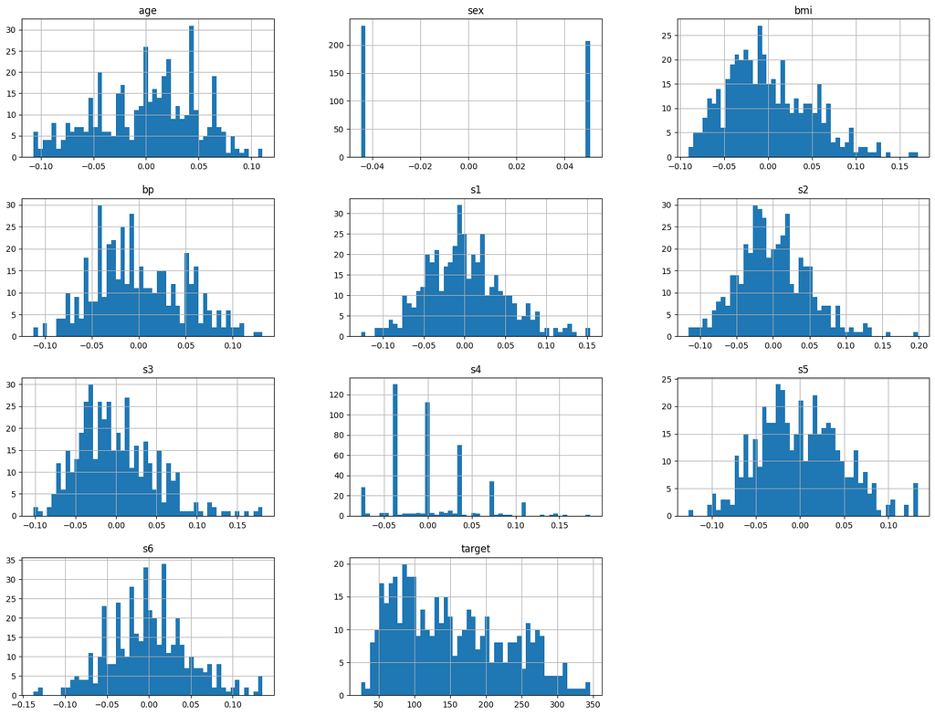

```python
# Histograms for each feature
import matplotlib.pyplot as plt
df.hist(bins=50, figsize=(20,15))
plt.show()
```

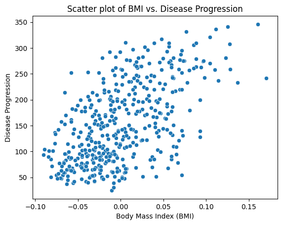

```python
# Scatter plot for BMI and target
import seaborn as sns
sns.scatterplot(x=df['bmi'], y=df['target'])
plt.xlabel('Body Mass Index (BMI)')
plt.ylabel('Disease Progression')
plt.title('Scatter plot of BMI vs. Disease Progression')
plt.show()
```

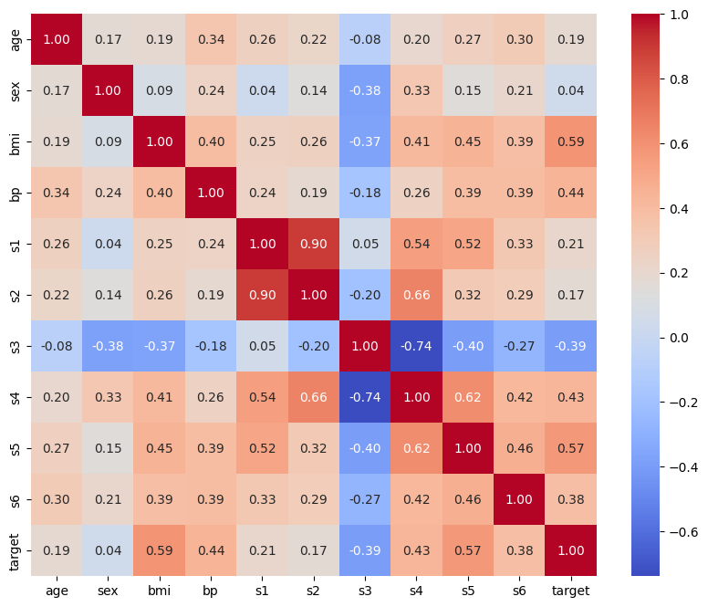

```python
# Correlation matrix
corr_matrix = df.corr()
plt.figure(figsize=(10, 8))
sns.heatmap(corr_matrix, annot=True, cmap='coolwarm', fmt=".2f")
plt.show()
```

### Descriptive Statistics

Scaling: All features are scaled and centered around a zero mean, demonstrating their standardization. Target Variation: The target variable, which shows the course of the disease, has a mean of 152.13 and varies greatly from 25 to 346.

### The Histogram

Normal Distributions: Blood pressure and BMI are two examples of features that have roughly normal distributions, which is advantageous for many statistical models. Bimodal Features: Bimodal distributions are displayed by some features, such as S4 (insulin sensitivity), which indicate distinct subgroups within the data. Skewness and Outliers: The majority of features have a fairly symmetrical distribution around the mean; neither notable skewness nor outliers are seen.

### Scatter plot

MI vs. Disease Progression: The scatter plot shows that BMI and disease progression have a moderately positive relationship. In keeping with medical predictions, the trend indicates a higher BMI may be linked to a higher rate of illness development. But the dispersion also suggests a significant variability that cannot be entirely explained by BMI alone.

### Correlation Matrix

Key Relationships: Correlated biochemical characteristics such as total serum cholesterol (S1) and low-density lipoproteins (S2) exhibit strong positive relationships. Important Predictors: Blood pressure, S5 (which is associated with insulin or glucose levels), and BMI had the strongest relationships with the objective, suggesting that they may be used as indicators of how a condition may proceed.

### Conclusion

Since there are no extreme outliers or missing values in the well-preprocessed data, modeling is made easier. The three main characteristics that should be prioritized for accurately forecasting the course of diabetes are BMI, blood pressure, and S5.

## 4. Clean the data if needed, and explain your reasoning for your reader

```python
# Check for missing values
print(df.isnull().sum())
```

```
age       0
sex       0
bmi       0
bp        0
s1        0
s2        0
s3        0
s4        0
s5        0
s6        0
target    0
dtype: int64
```

## 5. Split the dataset to a train (75%) and validation set (10%), and test set (15%).

```python
# Splitting the data
from sklearn.model_selection import train_test_split
train_set, temp_set = train_test_split(df, test_size=0.25, random_state=42)
validation_set, test_set = train_test_split(temp_set, test_size=0.6, random_state=42)  # 0.6 * 0.25 = 0.15

# To display the first few rows of the training set
print("Training Set:")
print(train_set.head())

# To display the first few rows of the validation set
print("\nValidation Set:")
print(validation_set.head())

# To display the first few rows of the test set
print("\nTest Set:")
print(test_set.head())
```

```
Training Set:
          age       sex       bmi        bp        s1        s2        s3  \
16  -0.005515 -0.044642  0.042296  0.049415  0.024574 -0.023861  0.074412
408  0.063504 -0.044642 -0.050396  0.107944  0.031454  0.019354 -0.017629
432  0.009016 -0.044642  0.055229 -0.005670  0.057597  0.044719 -0.002903
316  0.016281  0.050680  0.014272  0.001215  0.001183 -0.021355 -0.032356
3   -0.089063 -0.044642 -0.011595 -0.036656  0.012191  0.024991 -0.036038

           s4        s5        s6  target
16  -0.039493  0.052277  0.027917   166.0
408  0.023608  0.058038  0.040343   189.0
432  0.023239  0.055686  0.106617   173.0
316  0.034309  0.074966  0.040343   220.0
3    0.034309  0.022688 -0.009362   206.0

Validation Set:
          age       sex       bmi        bp        s1        s2        s3  \
5   -0.092695 -0.044642 -0.040696 -0.019442 -0.068991 -0.079288  0.041277
360  0.016281 -0.044642  0.020739  0.021872 -0.013953 -0.013214 -0.006584
137  0.005383 -0.044642  0.049840  0.097615 -0.015328 -0.016345 -0.006584
15  -0.052738  0.050680 -0.018062  0.080401  0.089244  0.107662 -0.039719
411  0.005383 -0.044642  0.058463 -0.043542 -0.073119 -0.072399  0.019187

           s4        s5        s6  target
5   -0.076395 -0.041176 -0.096346    97.0
360 -0.002592  0.013317  0.040343   281.0
137 -0.002592  0.017036 -0.013504   280.0
15   0.108111  0.036060 -0.042499   171.0
411 -0.076395 -0.051404 -0.025930   136.0

Test Set:
          age       sex       bmi        bp        s1        s2        s3  \
176  0.045341  0.050680  0.019662  0.039087  0.020446  0.025930  0.008142
429 -0.041840 -0.044642 -0.033151 -0.022885  0.046589  0.041587  0.056003
73   0.012648  0.050680 -0.020218 -0.002228  0.038334  0.053174 -0.006584
255  0.001751 -0.044642 -0.065486 -0.005670 -0.007073 -0.019476  0.041277
218 -0.041840 -0.044642 -0.065486 -0.040099 -0.005697  0.014344 -0.043401

           s4        s5        s6  target
176 -0.002592 -0.003301  0.019633   237.0
429 -0.024733 -0.025953 -0.038357    94.0
73   0.034309 -0.005142 -0.009362   111.0
255 -0.039493 -0.003301  0.007207   153.0
218  0.034309  0.007027 -0.013504   214.0
```

# PART 2

## 6. Models: a univariate polynomial regression on the BMI feature versus the "disease progression one year after baseline" - from degree 0 to 5 (6 models)

```python
import numpy as np
from sklearn.preprocessing import PolynomialFeatures
from sklearn.linear_model import LinearRegression
from sklearn.metrics import mean_squared_error, r2_score, mean_absolute_error

# To define a function to calculate MAPE
def mean_absolute_percentage_error(y_true, y_pred):
    y_true, y_pred = np.array(y_true), np.array(y_pred)
    return np.mean(np.abs((y_true - y_pred) / y_true)) * 100 if np.all(y_true != 0) else np.nan

# Extracting BMI and target from datasets
X_train_bmi = train_set[['bmi']].values
y_train = train_set['target'].values
X_val_bmi = validation_set[['bmi']].values
y_val = validation_set['target'].values

# Lists to store results for each polynomial degree
degrees = range(6)
results = []

for degree in degrees:
    # Create polynomial features
    poly = PolynomialFeatures(degree=degree)
    X_train_poly = poly.fit_transform(X_train_bmi)
    X_val_poly = poly.transform(X_val_bmi)

    # Fit a linear regression model
    model = LinearRegression()
    model.fit(X_train_poly, y_train)

    # Predicting on training and validation data
    y_train_pred = model.predict(X_train_poly)
    y_val_pred = model.predict(X_val_poly)

    # Calculate performance metrics
    train_r2 = r2_score(y_train, y_train_pred)
    val_r2 = r2_score(y_val, y_val_pred)
    train_mae = mean_absolute_error(y_train, y_train_pred)
    val_mae = mean_absolute_error(y_val, y_val_pred)
    train_mape = mean_absolute_percentage_error(y_train, y_train_pred)
    val_mape = mean_absolute_percentage_error(y_val, y_val_pred)

    # Store results in a dictionary
    results.append({
        'Degree': degree,
        'Train R^2': train_r2,
        'Validation R^2': val_r2,
        'Train MAE': train_mae,
        'Validation MAE': val_mae,
        'Train MAPE': train_mape,
        'Validation MAPE': val_mape
    })

# To display results
print("Degree | Train R^2 | Validation R^2 | Train MAE | Validation MAE | Train MAPE | Validation MAPE")
for result in results:
    print(f"{result['Degree']}      | {result['Train R^2']:.4f}   | {result['Validation R^2']:.4f}         | {result['Train MAE']:.2f}      | {result['Validation MAE']:.2f}         | {result['Train MAPE']:.2f}%      | {result['Validation MAPE']:.2f}%")
```

```
Degree | Train R^2 | Validation R^2 | Train MAE | Validation MAE | Train MAPE | Validation MAPE
0      | 0.0000   | -0.1070         | 66.20      | 66.06         | 62.83%      | 71.26%
1      | 0.3497   | 0.3313         | 52.29      | 47.21         | 48.36%      | 47.06%
2      | 0.3508   | 0.3316         | 52.21      | 47.21         | 48.30%      | 47.24%
3      | 0.3508   | 0.3316         | 52.20      | 47.19         | 48.28%      | 47.22%
4      | 0.3530   | 0.3408         | 52.09      | 46.09         | 48.05%      | 46.05%
5      | 0.3541   | 0.3499         | 52.06      | 45.46         | 48.00%      | 45.18%
```

## 7. Compare the models using the training and validation data. Construct a table summarizing the train validation results. Each model should have a separate row in the table (3 points):

```
1. R-Squared
2. Mean Absolute Error (MAE)
3. MAPE
```

| Degree | Train R^2 | Validation R^2 | Train MAE | Validation MAE | Train MAPE | Validation MAPE |
| --- | --- | --- | --- | --- | --- | --- |
| 0 | 0.0000 | -0.1070 | 66.20 | 66.06 | 62.83% | 71.26% |
| 1 | 0.3497 | 0.3313 | 52.29 | 47.21 | 48.36% | 47.06% |
| 2 | 0.3508 | 0.3316 | 52.21 | 47.21 | 48.30% | 47.24% |
| 3 | 0.3508 | 0.3316 | 52.20 | 47.19 | 48.28% | 47.22% |
| 4 | 0.3530 | 0.3408 | 52.09 | 46.09 | 48.05% | 46.05% |
| 5 | 0.3541 | 0.3499 | 52.06 | 45.46 | 48.00% | 45.18% |

R-Squared: As polynomial degrees increase, performance gets better. The degree 5 model captures the most variance across tested models, as evidenced by its best R-squared of 0.3541 for training and 0.3499 for validation.

Mean Absolute Error (MAE): As model complexity grows, MAE falls. With training and validation MAE values of 52.06 and 45.46, respectively, the fifth-degree polynomial shows the lowest values, indicating a tighter fit around the data points.

## 8. Identify the best model based on the table above.

```python
# Assuming degree 5 model is chosen based on highest Validation R^2 and lowest MAE & MAPE
best_degree = 5
```

The best option among the models that were analyzed, according to the metrics analysis, is the fifth-degree polynomial model. It consistently displays the lowest error rates (MAE and MAPE) and the highest R-Squared in both the training and validation datasets. This suggests that it not only successfully fits the training data but also successfully generalizes to the validation set, which is data that has not yet been seen.

Therefore, using the data in the table, the degree 5 polynomial regression model would be the optimum model to utilize for operational usage or additional testing. This model provides the most reliable predictive performance, minimizing mistakes in BMI-based diabetes progression predictions while striking a balance between accuracy and complexity.

## 9. Run the chosen model on the test set and provide results (R-Squared, MAPE, MAE)

```python
# To check if 'test_set' is properly loaded and contains 'bmi' and 'target' columns
if 'test_set' in locals() or 'test_set' in globals():
    if 'bmi' in test_set.columns and 'target' in test_set.columns:
        X_test_bmi = test_set[['bmi']].values  # Ensure this is reshaped correctly if it's a single feature
        y_test = test_set['target'].values
    else:
        print("Error: 'bmi' or 'target' columns are missing from the test set.")
else:
    print("Error: 'test_set' is not defined. Make sure your dataset is loaded and split correctly.")
```

```python
from sklearn.preprocessing import PolynomialFeatures
from sklearn.linear_model import LinearRegression
from sklearn.metrics import r2_score, mean_absolute_error


def mean_absolute_percentage_error(y_true, y_pred):
    y_true, y_pred = np.array(y_true), np.array(y_pred)
    return np.mean(np.abs((y_true - y_pred) / y_true)) * 100 if np.all(y_true != 0) else np.nan

# Assuming 'best_degree' has been determined from our validation process
best_degree = 5
poly = PolynomialFeatures(degree=best_degree)
X_train_poly = poly.fit_transform(X_train_bmi)  # Transform training data
model = LinearRegression()
model.fit(X_train_poly, y_train)  # To fit the model

# Transform the test data
X_test_poly = poly.transform(X_test_bmi)

# Predict on the test set
y_test_pred = model.predict(X_test_poly)

# Calculate R-Squared, MAE, and MAPE
test_r2 = r2_score(y_test, y_test_pred)
test_mae = mean_absolute_error(y_test, y_test_pred)
test_mape = mean_absolute_percentage_error(y_test, y_test_pred)

# Display the test results
print(f"Test R-Squared: {test_r2:.3f}")
print(f"Test MAE: {test_mae:.2f}")
print(f"Test MAPE: {test_mape:.2f}%")
```

```
Test R-Squared: 0.267
Test MAE: 51.75
Test MAPE: 43.03%
```

## 10. Plot a graph of the train, validation and test data points, and the fit of the chosen model over each of them (1 point).

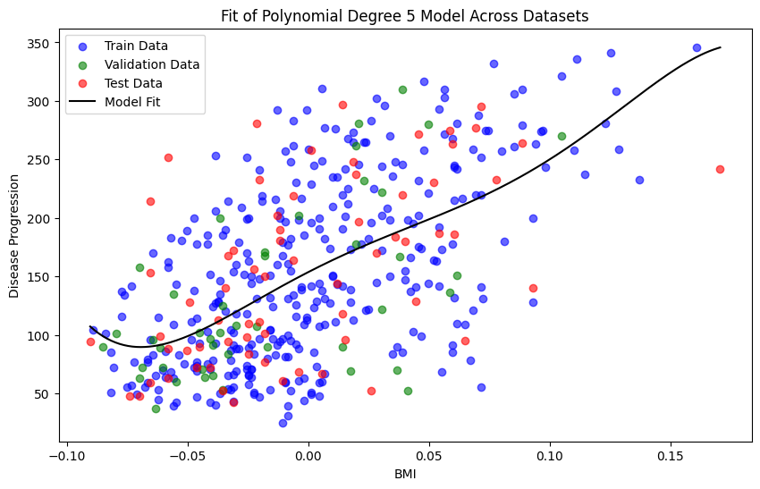

```python
import matplotlib.pyplot as plt
import numpy as np

# Prepare polynomial features transformation based on the best degree
poly = PolynomialFeatures(degree=5)

# Fit and transform on the entire training dataset for the purpose of plotting
X_train_poly = poly.fit_transform(X_train_bmi)
X_val_poly = poly.transform(X_val_bmi)
X_test_poly = poly.transform(X_test_bmi)

# Train the model
model = LinearRegression()
model.fit(X_train_poly, y_train)

# Generating predictions for a smooth curve on the plot
x_range = np.linspace(min(X_train_bmi.min(), X_val_bmi.min(), X_test_bmi.min()),
                      max(X_train_bmi.max(), X_val_bmi.max(), X_test_bmi.max()), 300).reshape(-1, 1)
x_range_poly = poly.transform(x_range)
predictions = model.predict(x_range_poly)

# Plotting
plt.figure(figsize=(10, 6))
plt.scatter(X_train_bmi, y_train, color='blue', label='Train Data', alpha=0.6)
plt.scatter(X_val_bmi, y_val, color='green', label='Validation Data', alpha=0.6)
plt.scatter(X_test_bmi, y_test, color='red', label='Test Data', alpha=0.6)
plt.plot(x_range, predictions, color='black', label='Model Fit')
plt.title('Fit of Polynomial Degree 5 Model Across Datasets')
plt.xlabel('BMI')
plt.ylabel('Disease Progression')
plt.legend()
plt.show()
```

## 11. Write down the equation of the best model (with a two decimal digit precision, assuming it's sufficient) (1 point).

```python
# Assuming that 'model' is already trained and 'poly' is our PolynomialFeatures transformer for degree 5
coefficients = model.coef_
intercept = model.intercept_

# Generating the polynomial equation as a string
equation_terms = [f"{coeff:.2f}*BMI^{i}" if i > 0 else f"{coeff:.2f}" for i, coeff in enumerate(coefficients)]
equation = " + ".join(equation_terms)
equation = f"{intercept:.2f} + {equation}"

# Print the polynomial equation
print("The equation of the best model (degree 5):")
print(f"y = {equation}")
```

```
The equation of the best model (degree 5):
y = 153.65 + 0.00 + 1059.89*BMI^1 + -3824.15*BMI^2 + -16770.23*BMI^3 + 753722.52*BMI^4 + -2993716.57*BMI^5
```

## 12. Calculate the expected diabetes progression for a BMI value of your choice using `model.perdict()` for that value (0.5 point).

```python
import numpy as np
from sklearn.preprocessing import PolynomialFeatures
from sklearn.linear_model import LinearRegression

# Example BMI value
bmi_value = np.array([[25.0]])  # Ensure it's a 2D array for sklearn

# Assuming 'poly' is the PolynomialFeatures instance used for the model
bmi_poly = poly.transform(bmi_value)

# Assuming 'model' is our trained fifth-degree polynomial regression model
predicted_progression = model.predict(bmi_poly)

# Output the predicted diabetes progression
print(f"Predicted diabetes progression for BMI value of {bmi_value[0][0]}: {predicted_progression[0]:.2f}")
```

```
Predicted diabetes progression for BMI value of 25.0: -28941354951607.38
```

## 13. How many trainable parameters are we fitting for each of the models? Explain these values. One way is to use sklearn function `get_feature_names_out()`.

```python
from sklearn.preprocessing import PolynomialFeatures

# Example: generate feature names for models of degrees 1 through 5
for degree in range(1, 6):
    poly = PolynomialFeatures(degree=degree)
    # Assume X_train_bmi is our training data for the feature 'bmi'
    poly.fit(X_train_bmi)
    feature_names = poly.get_feature_names_out(['bmi'])
    num_parameters = len(feature_names)  # The number of trainable parameters
    print(f"Degree {degree}:")
    print("Feature names (trainable parameters):", feature_names)
    print("Total number of parameters:", num_parameters, "\n")
```

```
Degree 1:
Feature names (trainable parameters): ['1' 'bmi']
Total number of parameters: 2

Degree 2:
Feature names (trainable parameters): ['1' 'bmi' 'bmi^2']
Total number of parameters: 3

Degree 3:
Feature names (trainable parameters): ['1' 'bmi' 'bmi^2' 'bmi^3']
Total number of parameters: 4

Degree 4:
Feature names (trainable parameters): ['1' 'bmi' 'bmi^2' 'bmi^3' 'bmi^4']
Total number of parameters: 5

Degree 5:
Feature names (trainable parameters): ['1' 'bmi' 'bmi^2' 'bmi^3' 'bmi^4' 'bmi^5']
Total number of parameters: 6
```

## 14. Provide a conclusion section. In particular, do a deep dive on where the model fails, and add a short section in the conclusions that describes the model limitations. This should be in addition to summarizing it performance.

For future modeling:

Think about adding more features and controlling overfitting with regularization techniques. Examine more straightforward models or ones that provide a better way to balance interpretability and accuracy, including ensemble approaches or linear regression with specific interactions. In order to guarantee dependability and relevance in real-world situations, this analysis emphasizes the necessity of meticulous model selection and validation.

# PART 3

## In this part, use all features in the dataset, or drop some features per your discretion based on the EDA.

Repeat the steps in part 2 for the following models: 1. Two polynomial models (degrees >1, of your choice) 2. Two decision trees (e.g. consider changing the `max_depth` hyperparameter) 3. Two kNNs

## 1. Two polynomial models (degrees >1, of your choice)

```python
from sklearn import datasets
from sklearn.model_selection import train_test_split
from sklearn.preprocessing import StandardScaler

# Load the dataset
diabetes = datasets.load_diabetes()
X = diabetes.data
y = diabetes.target

# Optional: Standardize the dataset
scaler = StandardScaler()
X_scaled = scaler.fit_transform(X)

# Split the dataset into training and validation sets
X_train, X_temp, y_train, y_temp = train_test_split(X_scaled, y, test_size=0.25, random_state=42)
X_val, X_test, y_val, y_test = train_test_split(X_temp, y_temp, test_size=0.6, random_state=42)
```

```python
from sklearn.preprocessing import PolynomialFeatures
from sklearn.linear_model import LinearRegression
from sklearn.pipeline import make_pipeline
from sklearn.metrics import r2_score, mean_absolute_error

# Assuming that the split is done and X_train, y_train are correctly defined
for degree in [2, 4]:
    poly_model = make_pipeline(PolynomialFeatures(degree), LinearRegression())
    poly_model.fit(X_train, y_train)  # Train the model
    y_val_pred = poly_model.predict(X_val)  # Predict on the validation set

    # Print the R^2 and MAE for validation set
    print(f"Polynomial Degree {degree} - Validation R^2: {r2_score(y_val, y_val_pred):.2f}")
    print(f"Polynomial Degree {degree} - Validation MAE: {mean_absolute_error(y_val, y_val_pred):.2f}")
```

[output not shown]

## 2. Two decision trees (e.g. consider changing the `max_depth` hyperparameter)

```python
from sklearn.tree import DecisionTreeRegressor

# Decision Trees with different depths
for depth in [3, 5]:
    tree_model = DecisionTreeRegressor(max_depth=depth)
    tree_model.fit(X_train, y_train)
    y_val_pred = tree_model.predict(X_val)
    print(f"Decision Tree Depth {depth} - Validation R^2: {r2_score(y_val, y_val_pred):.2f}")
```

```
Decision Tree Depth 3 - Validation R^2: 0.20
Decision Tree Depth 5 - Validation R^2: 0.04
```

## 3. Two kNNs

```python
from sklearn.neighbors import KNeighborsRegressor

# kNN models with 5 and 10 neighbors
for neighbors in [5, 10]:
    knn_model = KNeighborsRegressor(n_neighbors=neighbors)
    knn_model.fit(X_train, y_train)
    y_val_pred = knn_model.predict(X_val)
    print(f"kNN with {neighbors} Neighbors - Validation R^2: {r2_score(y_val, y_val_pred):.2f}")
```

```
kNN with 5 Neighbors - Validation R^2: 0.36
kNN with 10 Neighbors - Validation R^2: 0.40
```

k-Nearest Neighbors (kNN): The kNN models performed better with an R2 of 0.36 for five neighbors and marginally better with ten neighbors, demonstrating that a bigger neighbor parameter improves generalization.